# Going from messy to Tidy data

In this tutorial, we will be working with data from the [Prison Policy Initiative](https://www.prisonpolicy.org/data/). The Prison Policy Initiative specializes in producing the information that you need to support campaigns for justice in different states in the United States. We will focus on incarcerated population numbers (rates per 100,000) by [race/ethnicity according to the 2010 census](https://www.prisonpolicy.org/data/race_ethnicity_gender_2010.xlsx).

# 1 Read data from an excel file

Download the [data](https://www.prisonpolicy.org/data/race_ethnicity_gender_2010.xlsx) and save it to a folder in your RStudio project. I saved the excel file in a folder called `data` in my project.

```r
# list contents of data folder
list.files(path = "data")
```

```
## [1] "race_ethnicity_gender_2010.xlsx"
```

Since the data file is an excel file, we need a special package to read the data in.

Install the package first.

```r
install.packages("readxl")
```

Then load the package using `library()`.

```r
library(readxl)
```

We can now use `read_excel()` to read the file in.

```r
incarceration_data_2010 <- read_excel("data/race_ethnicity_gender_2010.xlsx",
                                      sheet = "Total",
                                      skip = 4)
```

# 2 Tidy data

Let’s first load the `tidyverse` package so we can tidy the data up.

```r
library(tidyverse)
```

We are interested in Arizona data only. Let’s filter the data to keep `Geography == "Arizona"`.

```r
arizona_incarceration_2010 <- incarceration_data_2010 %>%
  filter(Geography == "Arizona")
```

The data is split into three blocks: raw counts for correctional data, comparable data, and incarceration rates per 100,000. This last block is the one we want to look into, since it has normalized counts by total population for each state. Let’s find out what column we need to select by looking into column names.

```r
colnames(arizona_incarceration_2010)
```

```
##  [1] "GEOID"
##  [2] "GEOID2"
##  [3] "Geography"
##  [4] "Total : In Correctional Facilities for Adults"
##  [5] "White alone : in Correctional Facilities for Adults"
##  [6] "Black or African American alone : in Correctional Facilities for Adults"
##  [7] "American Indian and Alaska Native alone : in Correctional Facilities for Adults"
##  [8] "Asian alone : in Correctional Facilities for Adults"
##  [9] "Native Hawaiian and other Pacific Islander alone : in Correctional Facilities for Adults"
## [10] "Some other race alone : in Correctional Facilities for Adults"
## [11] "Two or more races : in Correctional Facilities for Adults"
## [12] "Hispanic or Latino : in Correctional Facilities for Adults"
## [13] "White alone, not Hispanic or Latino : in Correctional Facilities for Adults"
## [14] "...14"
## [15] "Total Population"
```

[output cut: 20 more lines]

We need every column that starts with `"Incarceration rate"` in addition to the `Geography` column.

```r
arizona_incarceration_per100k_2010 <- arizona_incarceration_2010 %>%
  select(Geography,
    starts_with("Incarceration rate"))

arizona_incarceration_per100k_2010
```

```
## # A tibble: 1 x 11
##   Geography `Incarceration r… `Incarceration … `Incarceration … `Incarceration …
##   <chr>     <chr>             <chr>            <chr>            <chr>
## 1 Arizona   1060.18178612478… 774.78171232329… 3183.68544600939 2267.2318727679…
## # … with 6 more variables: Incarceration rate: Asian alone <chr>,
## #   Incarceration rate: Native Hawaiian and other Pacific Islander alone <chr>,
## #   Incarceration rate: Some other race alone <chr>,
## #   Incarceration rate: Two or more races <chr>,
## #   Incarceration rate: Hispanic or Latino <chr>,
## #   Incarceration rate: White alone, not Hispanic or Latino <chr>
```

As mentioned in one of the readings in this module, tidy data follows three rules:

- Each variable must have its own column.
- Each observation must have its own row.
- Each value must have its own cell.

R likes vectorized data, and having one column (i.e., a vector) per variable in your data makes data manipulation much easier. Also, as with your coding and documentation, choosing one consistent way of doing things (and sticking to it) helps to make your data analysis more robust. Choosing one way to represent data fits into this pattern of making everything consistent.

Looking at our Arizona incarceration data, it has three variables: location (which is Arizona for all observations), race and ethnic group, and rate of incarceration. For our main categorical variable, race and ethnic group, we have the levels of this variable (e.g., White alone, Black or African American alone) as column names instead of it being its own variable/column in the data. Our numeric variable, rate of incarceration, is spread across these different columns. We need to pivot the data longer, making the column names into one variable/column in the data and gathering the values into another column for our incarceration rate.

We will pivot every column except `Geography` (hence the minus in from of `Geography` after `cols =`, meaning *except*). We will also set the prefix for these columns (`"Incarceration rate: "`), so the prefix is removed. The column names will go into a column called `race_enthnicity` and the values will go into a column called `incarceration_rate`.

```r
# create new tidy version of the data starting with arizona data and then
# pivot all columns except Geography, with prefix for column names set for
# "Incarceration rate: " and setting the values column name to incarceration_rate
# and the column names column name to race_ethnicity
arizona_incarc_per100k_2010_tidy <- arizona_incarceration_per100k_2010 %>%
  pivot_longer(cols = -Geography,
               names_prefix = "Incarceration rate: ",
               values_to = "incarceration_rate",
               names_to = "race_ethnicity")

# inspect data
glimpse(arizona_incarc_per100k_2010_tidy)
```

```
## Rows: 10
## Columns: 3
## $ Geography          <chr> "Arizona", "Arizona", "Arizona", "Arizona", "Arizon…
## $ race_ethnicity     <chr> "Incarceration rate", "White alone", "Black or Afri…
## $ incarceration_rate <chr> "1060.1817861247866", "774.78171232329316", "3183.6…
```

As it is often the case when reading data from excel files, the numeric variable `incarceration_rate` is not an actual numeric variable yet. We can use `mutate()` to and `parse_number()` to change it from character to numeric.

```r
arizona_incarc_per100k_2010_tidy <- arizona_incarc_per100k_2010_tidy %>%
  mutate(incarceration_rate = parse_number(incarceration_rate))
```

Our data is now tidy.

```r
arizona_incarc_per100k_2010_tidy
```

```
## # A tibble: 10 x 3
##    Geography race_ethnicity                                   incarceration_rate
##    <chr>     <chr>                                                         <dbl>
##  1 Arizona   Incarceration rate                                            1060.
##  2 Arizona   White alone                                                    775.
##  3 Arizona   Black or African American alone                               3184.
##  4 Arizona   American Indian and Alaska Native alone                       2267.
##  5 Arizona   Asian alone                                                    643.
##  6 Arizona   Native Hawaiian and other Pacific Islander alone              8136.
##  7 Arizona   Some other race alone                                         1690.
##  8 Arizona   Two or more races                                              732.
##  9 Arizona   Hispanic or Latino                                            1453.
## 10 Arizona   White alone, not Hispanic or Latino                            633.
```

# 3 Visualize data

Let’s visualize our data, to ensure everything looks good. With our variables being column names in our tidy data, we can map our categorical variable for race and ethnicity to the `y` axis (ordered by incarceration rate) and we can also map our numeric variable to the `x` axis.

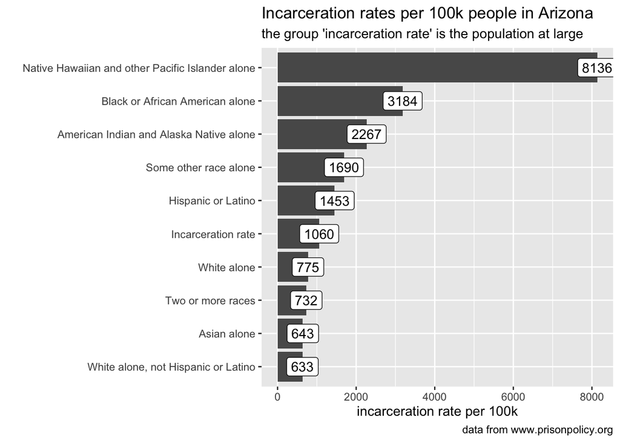

```r
arizona_incarc_per100k_2010_tidy %>%
  ggplot(aes(y = reorder(race_ethnicity, incarceration_rate) ,
             x = incarceration_rate)) +
  geom_col() +
  geom_label(aes(label = round(incarceration_rate, digits = 0))) +
  labs(y = "",
       x = "incarceration rate per 100k",
       caption = "data from www.prisonpolicy.org",
       title = "Incarceration rates per 100k people in Arizona",
       subtitle = "the group 'incarceration rate' is the population at large")
```

# 4 Save tidy data to disk

Once you are happy with your data, make sure you save it to a different file, clearly names, to disk, so you can use it in the future without having to run the entire data wrangling script again.

```r
arizona_incarc_per100k_2010_tidy %>%
  write_csv("data/arizona-incarceration-2010.csv")
```

> Reflection: How would you present the visualization above to make the point of racial disparity? How would you offer context, challenge associations, and highlight institutions to ensure people use this information to effect social change?